# Siniestros fatales en tránsito, Uruguay 2013-2017

25 de junio de 2018

## Introducción:

El presente estudio surge de la curiosidad por conocer el comportamiento de los siniestros de tránsitos en Uruguay y posee como objetivo madre una profunda aplicación de los conocimientos adquiridos en la asignatura “Nuevas técnicas para el análisis de datos”, marcando énfasis en un correcto análisis exploratorio y la generación de adecuadas visualizaciones de los datos. Se analizará tanto variables del fallecido como del suceso en sí. Tal análisis permitirá emitir conclusiones informativas que representen la realidad uruguaya en materia de siniestros fatales.

## Preguntas a responder:

1 - ¿Cuál es la distribución relativa por sexo y qué comportamiento posee la edad del fallecido en el período dado?

2 - ¿Existe relación entre el rol del fallecido tanto con la edad, como con el vehículo del difunto?

## Preguntas a responder:

5 - ¿Qué comportamiento posee la jurisdicción por sí misma, y según el tipo de siniestro ocurrido?

6 - ¿Cuál es la distribución de los días de supervivencia luego del accidente y qué proporción ocupa cada tipo de siniestro en caso de muerte súbita?

7 - ¿Cuál es la tasa de fallecidos por departamento?

8 - ¿Qué fechas y horarios poseen mayor frecuencia absoluta de difuntos?

## Hipótesis

- Se considera que el comportamiento de la edad estará dado por una fuerte densidad para edades cercanas a los 25 y una mayor proporción de difuntos para las personas de sexo masculino.
- Retomando el punto anterior, se asume una mayor proporción de fallecidos para peatones a altas edades, al contrario que en conductores. Los pasajeros poseerán una densidad equilibrada para todas las edades.
- Considerando la concentración de autos en el país, existe una alta probabilidad de fallecer en condición de peatón siendo impactado por dicho vehículo.
- Colisiones entre un vehículo de gran magnitud y otro de menor provocaría que el de menor quede expuesto a graves consecuencias.

## Hipótesis

- Se prevé mayor proporción de accidentes fatales en rutas nacionales, esto en base principalmente a la práctica de altas velocidades.
- Los tipos de siniestros que mayoritariamente se llevan vidas serán colisión entre vehículos e impacto con obstáculos. Tales impactos generían una muerte instantánea o de poca supervivencia para el individuo.
- Debido a la concentración en la zonas metropolitanas habra mas probabilidades de sufrir un accidentes de tráficos. En tanto la tasas de fallecidos en el país, las mayores tasas se encontraran en la zona anteriormente mencionadas.
- En meses de vacaciones se provocarían mayores accidentes de tráfico producto de congregaciones y movimientos en general. Respecto al día y hora se considera altas frecuencias absolutas para fines de semana en horarios nocturnos.

## Fuente de datos

Los datos se obtienen de la Unidad Nacional de Seguridad Vial (UNASEV) y corresponden al período comprendido entre 2013 y 2017.

Mediante su catálogo de datos abiertos se extraen las bases utilizadas, desde el siguiente url: http://unasev.gub.uy/inicio/sinatran/datos_abiertos/

### *Modelos y herramientas:*

Es importarte recordar los objetivos del estudio, uno de ellos guía a la implementación de apropiadas visualizaciones. Para esto se utilizará el software estadístico `R`, con la puntual aplicación de paquete `tidyverse`, que proporciona un conjunto de librerías óptimas para el análisis exploratorio de datos.

## Descripción de variables:

Se poseen 15 variables identificadas de la siguiente manera:

- **a:** Año en el que sucede el accidente.
- **fecha:** Día y mes del suceso.
- **hora:** Hora del mismo, formato horas y minutos.
- **dep:** Departamento de Uruguay donde sucede el mismo.
- **jur:** Jurisdicción, ya sea en rutas nacionales o dentro del departamento.
- **tipo.sin:** Tipo de siniestro en cuestión.
- **vehi:** Vehículo en que se transporta el individuo al momento del siniestro.

## Descripción de variables:

- **rol:** Rol que cumple el fallecido: conductor, pasajero y peatones.
- **edad:** Edad del fallecido medido en años.
- **Sexo:** Sexo del difunto: femenino o masculino.
- **f.dias:** Días de supervivencia luego del accidente, previo a su posterior muerte.
- **otro.vehi:** Otro posible vehículo involucrado en el accidente.
- **dir:** Lugar del accidente.
- **x:** Latitud correspondiente a la ubicación del accidente.
- **y:** Longitud correspondiente a la ubicación del accidente.

## Análisis de Datos

Inicialmente se llevó a cabo una profunda exploración de datos, la cual permitió además de conocer inconvenientes en la base, formular nuevas preguntas. Posterior a esto, se realizaron visualizaciones acordes con el fin de generar una respuesta clara y acorde a las dudas planteadas. A continuación se planean las mismas:

## Fallecidos por año

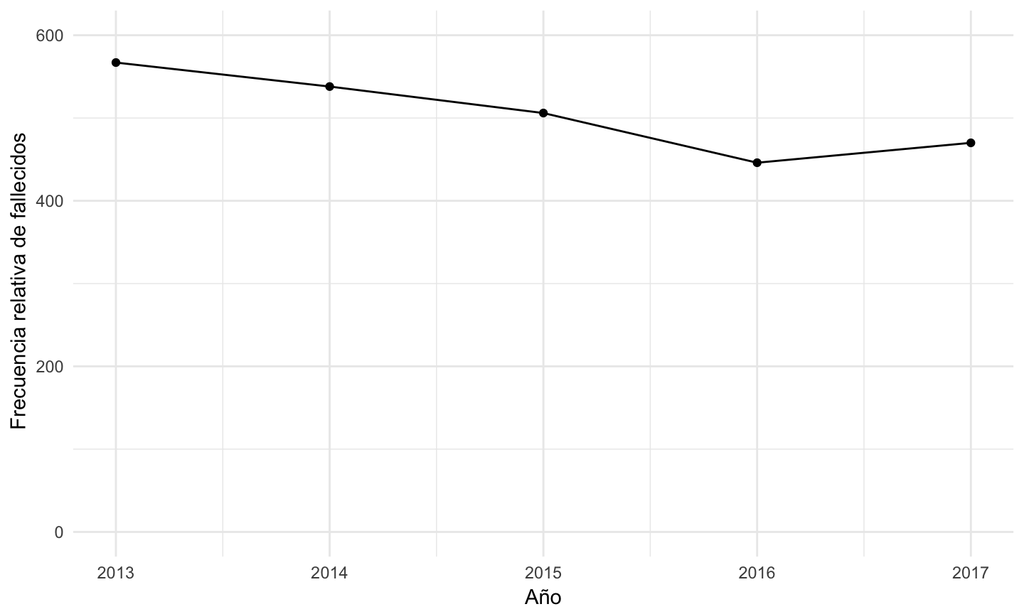

## Sexo

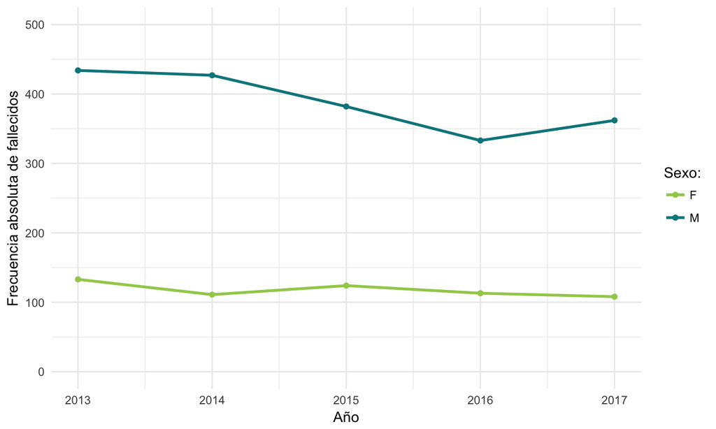

## Edad

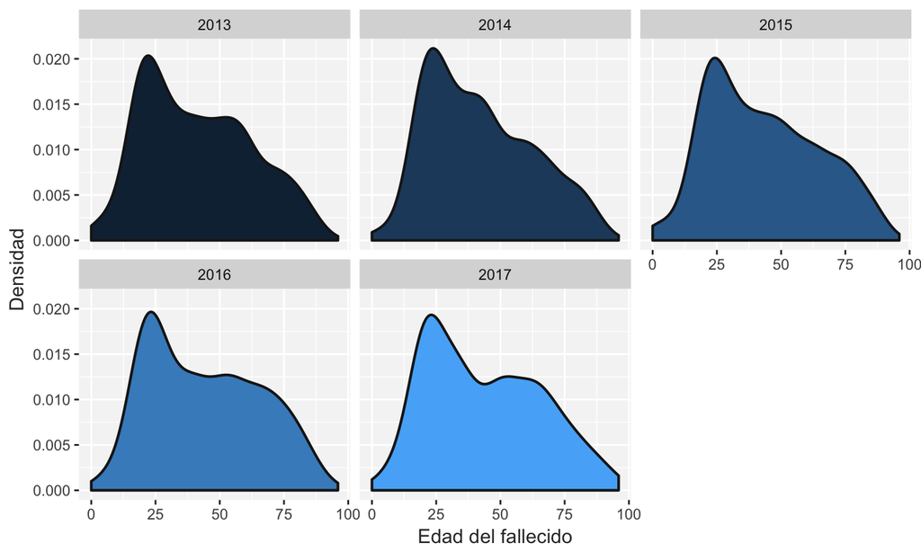

## Rol

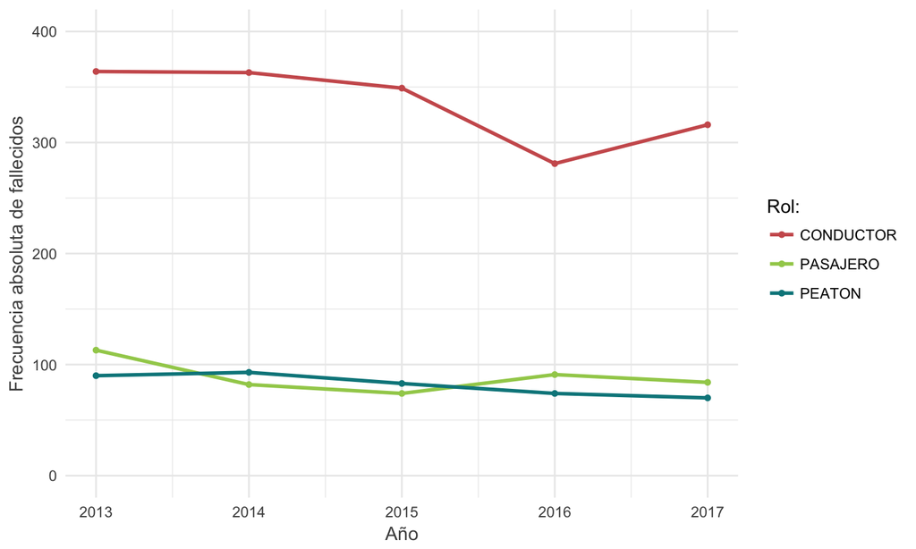

## Edad y Rol

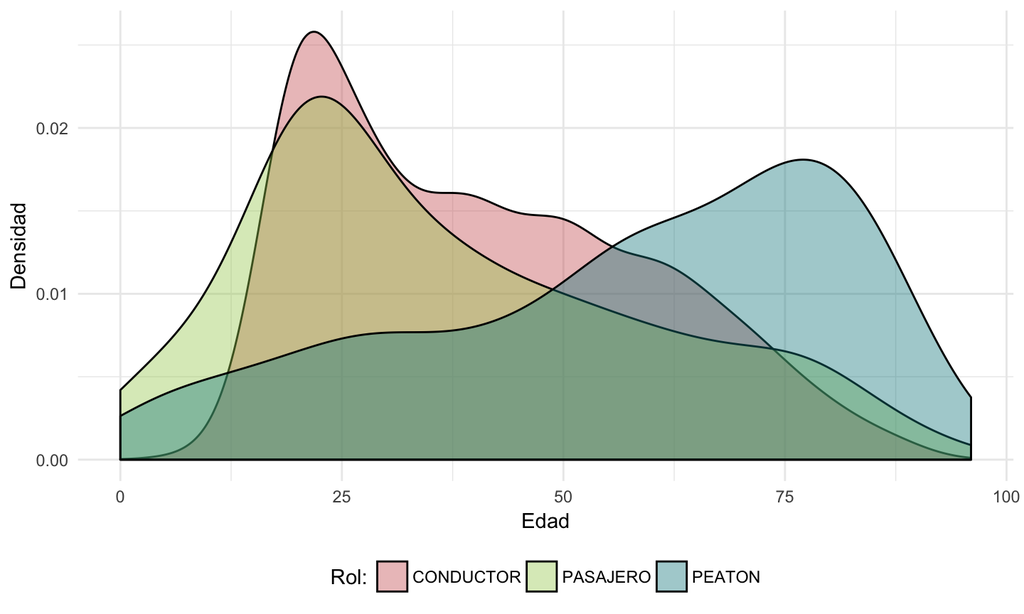

## Vehículo

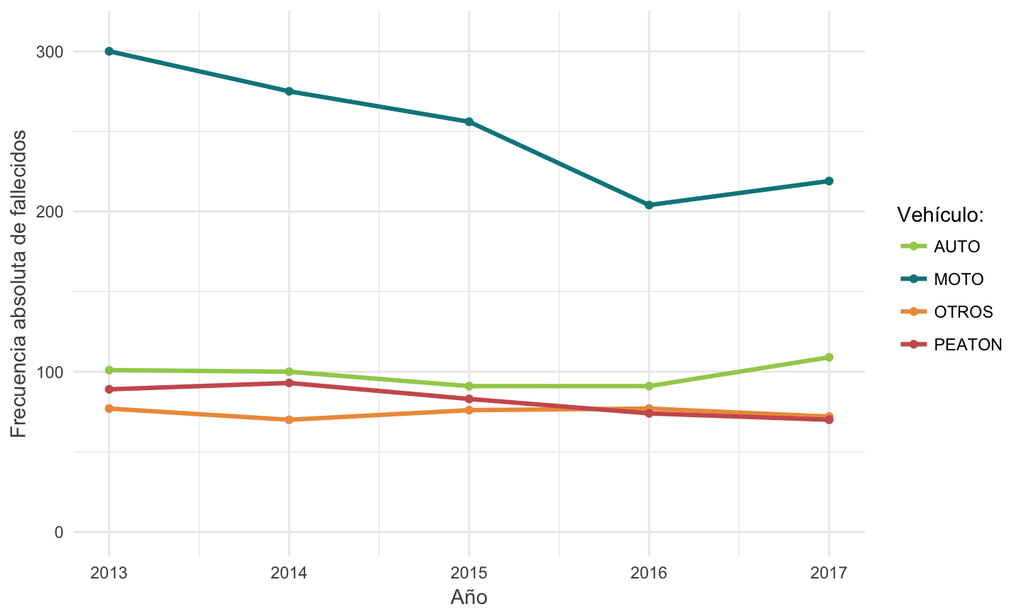

## Edad y Vehículo

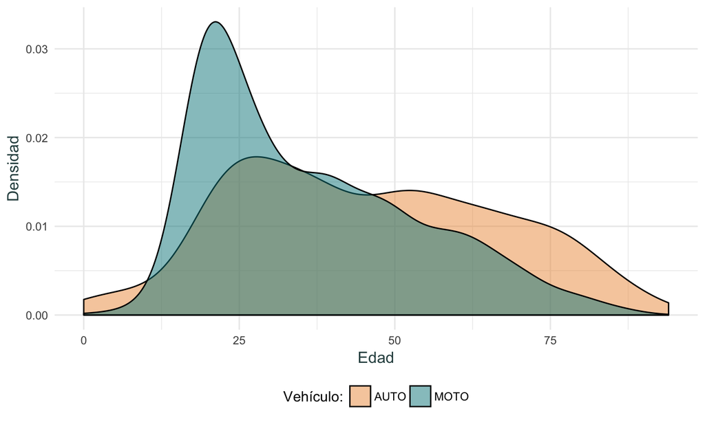

## Jurisdicción

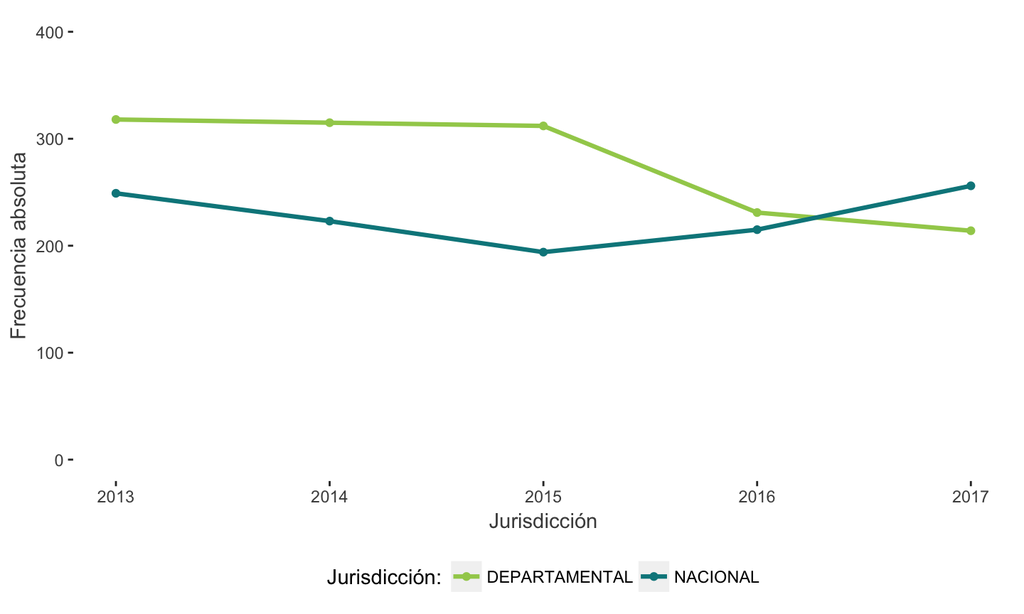

## Días de supervivencia

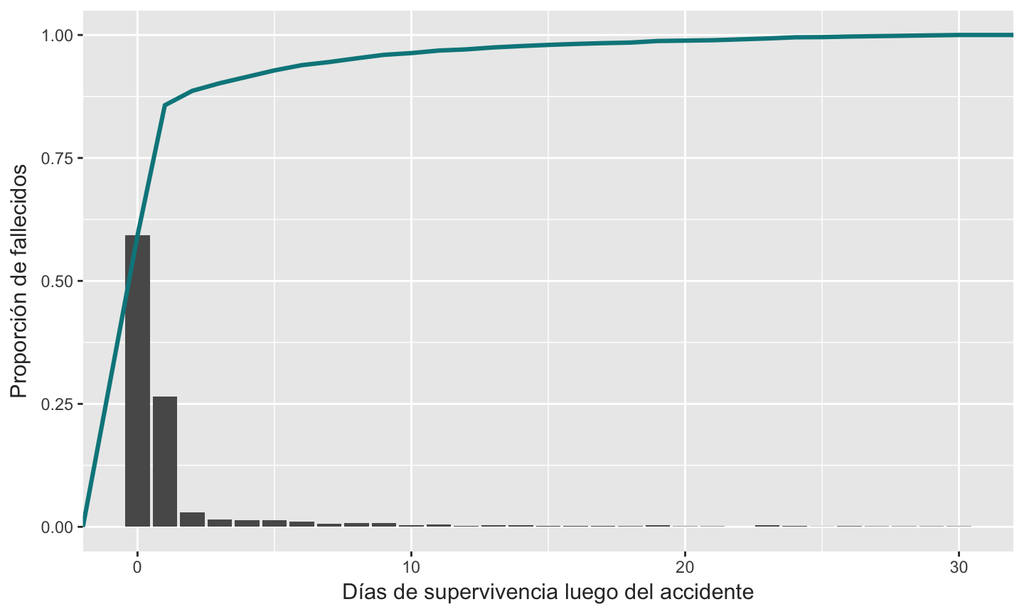

## Tipo de Siniestro

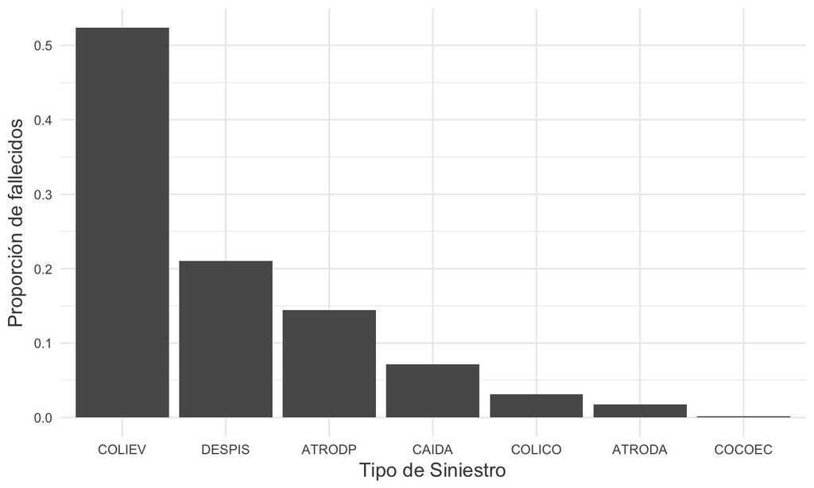

Gráfico de barras: proporción de fallecidos en muerte súbita según tipo de siniestro.

## Departamento

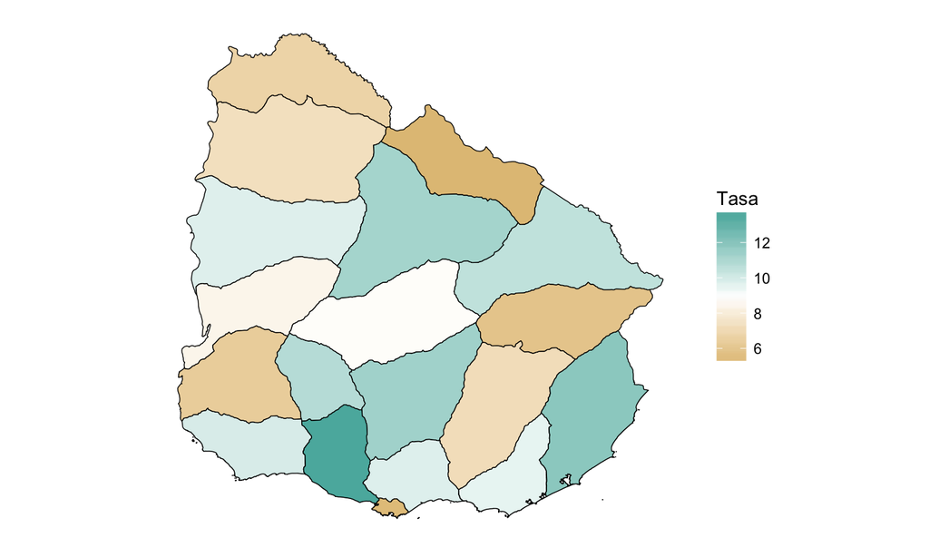

Gráfico de mapas: tasa de fallecidos en accidentes de tránsito cada 10 mil habitantes por departamento.

## Fecha y hora

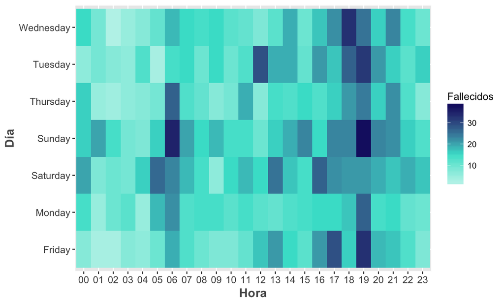

Diagrama térmico: frecuencia absoluta de fallecidos según día y hora del accidente.

## Conclusiones

Luego de la etapa analítica de los datos, con la utilización de dieferentes técnicas descriptivas y de visualización, procedemos a interpretar los resultados obtenidos, y contrastarlos con las hipótesis planteadas.

1- En la distribución por sexo se revela que el sexo masculino fallece aproximadamente 3 veces mas que sexo femenino. Respecto a la edad, hay una gran concentración de fallecidos en el intervalo 20 a 30 años.

2- El rol conductor posee entre 280 a 370 fallecidos por año mientras que peatones y pasajeros son unos 100 fallecidos por año aproximadamente. En el analisis del vehículo del difunto con respecto al rol que cumplia en el, se registro altas cantidades de fallecimiento para los conductores de motos y autos.

## Conclusiones

5- Hay un disminucion de fallecidos en jurisdicciones nacionales hasta el año 2015, donde creece tal que en el año 2017 supera a los fallecidos en departamentales.

## Conclusiones

6- Existe aproximadamente un 60% de probabilidad de fallecer al instante o no superar las 24 horas en caso de sufrir un accidene fatal, además de un 50% de las mismas son ocasionadas por colisiones entre vehículos.

7- La mayoría de los fallecimientos en siniestros de tránsito ocurren en la zona metropolitana, conformada por los departamentos de Montevideo, Maldonado, Canelones y San José. Con respecto a las tasas medidas cada 10 mil habitantes se refleja una realidad completamente diferente, con Rivera y Montevideo presentando las tasas más bajas del país.

8- Existe una clara concentración en la frecuencia absoluta de fallecidos para los horarios de 16:00 a 21:00 horas, la cual aumentando paulatinamente y se intensidad los fines de semana.

## Interpretación

Las siguientes explicaciones presentan cierto nivel de subjetividad en consecuencia a la limitación propia de los conocimientos adquiridos por los autores del presente informe, por lo cual es posible diferir en las mismas.

**¡MUCHAS GRACIAS!**